# Decorrelation-Based Benchmarking Regression: Personality Age

Jose Tamez

2024-03-08

# 1 Effect of UPSTM-Based Decorrelation on Regression fit

## 1.1 Loading the libraries

```r
library("FRESA.CAD")
library(readxl)
library(igraph)
library(umap)
library(tsne)
library(entropy)

op <- par(no.readonly = TRUE)
pander::panderOptions('digits', 3)
pander::panderOptions('table.split.table', 400)
pander::panderOptions('keep.trailing.zeros',TRUE)
```

## 1.2 Material

Data Source https://quantdev.ssri.psu.edu/tutorials/intro-basic-exploratory-factor-analysis

“For this example, we use data from the web that are collected and distributed at https://openpsychometrics.org/_rawdata/. The data were obtained from 19,719 participants (rows) who provided answers to the Big Five Personality Test, constructed with items from the International Personality Item Pool. Data columns include gender, age, race, native language, country, and answers to the 50 likert rated statements (1-5;0 if missed; 1 was labeled as “strongly disagree”, 2 was labeled as “disagree”, 3 was labeled as “neither agree not disagree”, 4 was labeled as “agree” and 5 was labeled as “strongly agree”.) The original files can be obtaned at http://openpsychometrics.org/_rawdata/BIG5.zip”

## 1.3 The Data

```r
BigData <- as.data.frame(read_excel("~/GitHub/LatentBiomarkers/Data/BigData.xlsx"))

BigData[BigData==0] <- NA
BigData <- BigData[complete.cases(BigData),]
BigData <- BigData[BigData$age<100,]

BigData <- BigData[,-c(1,3,5,6,7)]

BigData$gender <- 1*(BigData$gender==1)


BigData$age <- log10(BigData$age)
```

### 1.3.1 Standarize the names for the reporting

```r
studyName <- "PersonalityAge"
dataframe <- BigData
outcome <- "age"

thro <- 0.20
cexheat <- 0.5
loops  <- 10
tfrac <- 0.25
```

## 1.4 Generaring the report

### 1.4.1 Libraries

Some libraries

```r
library("pls")
```

### 1.4.2 CV interface

```r
plfit <- function(formula=formula,data=NULL,...)
{
  fitpls <- plsr(formula=formula,data=data,scale =TRUE,...)
  class(fitpls) <- c("TopPLS",class(fitpls))
  return(fitpls)
}

pcrfit <- function(formula=formula,data=NULL,...)
{
  fitpls <- pcr(formula=formula,data=data,scale =TRUE,...)
  class(fitpls) <- c("TopPLS",class(fitpls))
  return(fitpls)
}

cpplsfit <- function(formula=formula,data=NULL,...)
{
  fitpls <- cppls(formula=formula,data=data,scale =TRUE,...)
  class(fitpls) <- c("TopPLS",class(fitpls))
  return(fitpls)
}

predict.TopPLS <- function(object,...)
{
  parameters <- list(...);
    testData <- parameters[[1]];
    class(object) <- class(object)[2]
  pred <- predict(object,newdata=testData)
  return(pred[,1,object$ncomp])
}
```

## 1.5 PLSR vs ILAA

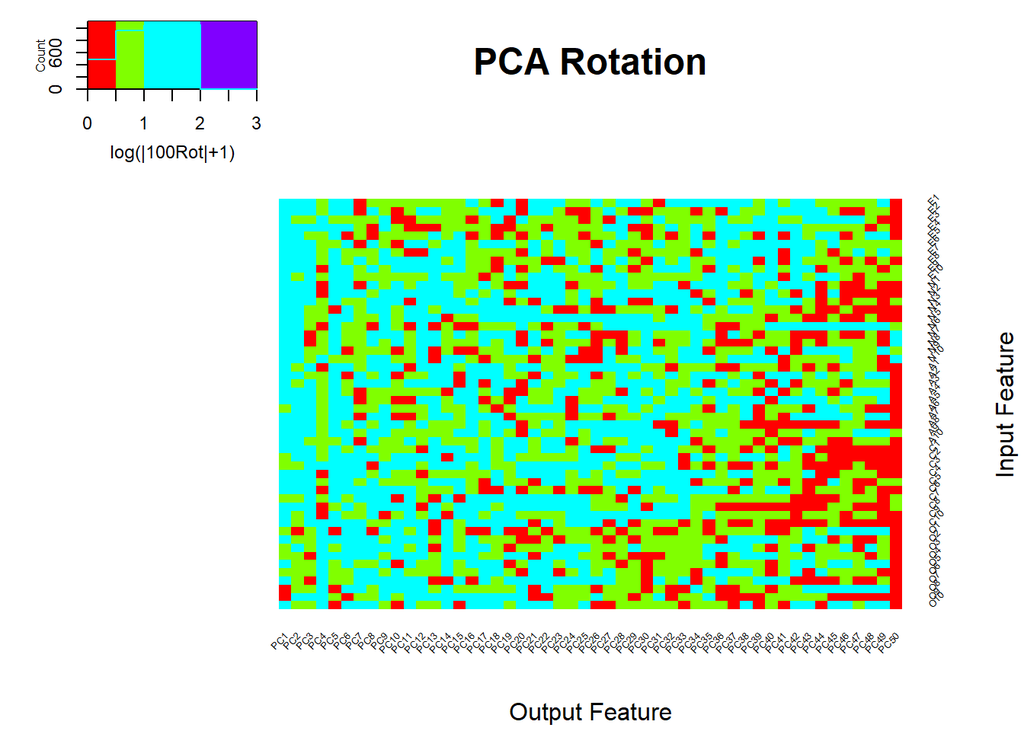

```r
toPCA <- sapply(apply(dataframe,2,unique),length) >= 5 & colnames(dataframe) != outcome

pc <- prcomp(dataframe[,toPCA],center = TRUE,scale. = TRUE,tol=0.01)   #principal components


rotstd <- log10(abs(100*pc$rotation)+1.0)
  gplots::heatmap.2(rotstd,
                    trace = "none",
                    dendrogram="none",
                    breaks=c(0,0.5,1,2,3),
#                    scale="row",
                    mar = c(5,5),
                    col=rainbow(4),
                    main = "PCA Rotation",
                    cexRow = cexheat,
                    cexCol = cexheat,
                    Rowv=FALSE,
                    Colv=FALSE,
                   srtCol=45,
                   srtRow=45,
                    key.title=NA,
                    key.xlab="log(|100Rot|+1)",
                    xlab="Output Feature", ylab="Input Feature")
```

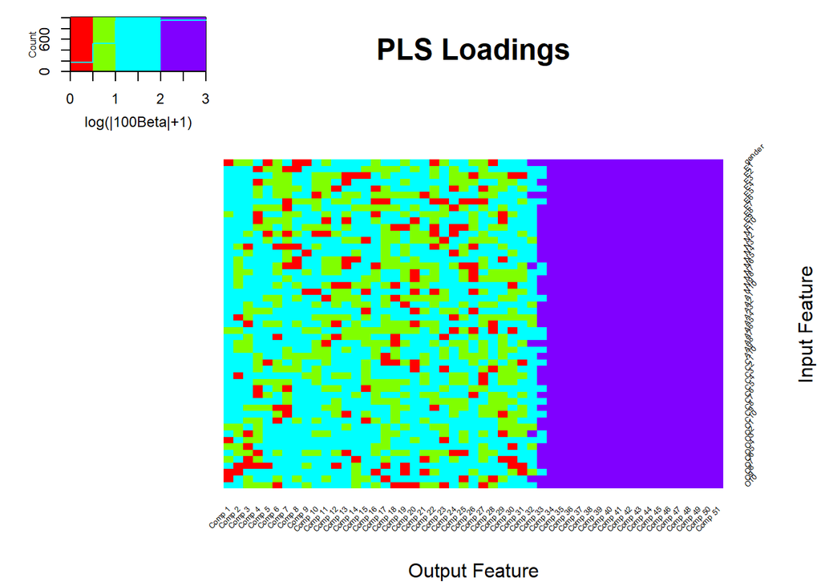

```r
plm <- plsr(formula=formula(paste(outcome,"~.")),data=dataframe,scale =TRUE)

loadadings <- log10(abs(100*plm$loadings) + 1.0)
  gplots::heatmap.2(loadadings,
                    breaks=c(0,0.5,1,2,3),
                    trace = "none",
                    dendrogram="none",
#                    scale="row",
                    mar = c(5,5),
                    col=rainbow(4),
                    main = "PLS Loadings",
                    cexRow = cexheat,
                    cexCol = cexheat,
                    Rowv=FALSE,
                    Colv=FALSE,
                   srtCol=45,
                   srtRow=45,
                    key.title=NA,
                    key.xlab="log(|100Beta|+1)",
                    xlab="Output Feature", ylab="Input Feature")
```

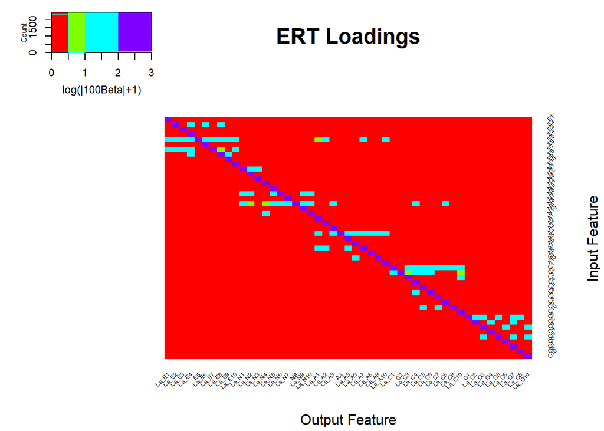

```r
ERTmod <- ILAA(dataframe,Outcome = outcome,thr=thro)

ERT <- log10(abs(100*attr(ERTmod,"UPLTM")) + 1);
  gplots::heatmap.2(ERT,
                    trace = "none",
                    breaks=c(0,0.5,1,2,3),
                    mar = c(5,5),
                    col=rainbow(4),
                    main = "ERT Loadings",
                    cexRow = cexheat,
                    cexCol = cexheat,
                    dendrogram="none",
                    Rowv=FALSE,
                    Colv=FALSE,
                   srtCol=45,
                   srtRow=45,
                    key.title=NA,
                    key.xlab="log(|100Beta|+1)",
                    xlab="Output Feature", ylab="Input Feature")
```

## 1.6 SOTA Comparison to PLS, PC, LASSO, and ENET

### 1.6.1 PLSR

```r
PLScv <- randomCV(dataframe,outcome,plfit,
                        trainFraction = tfrac,
                        repetitions = loops)
```

……….10 Tested: 19303 Avg. Selected: 0 Min Tests: 2 Max Tests: 10 Mean Tests: 7.500389 . MAD: 0.1185272

```r
PLSbs <- predictionStats_regression(PLScv$medianTest,"PLS: CV")
```

PLS: CV

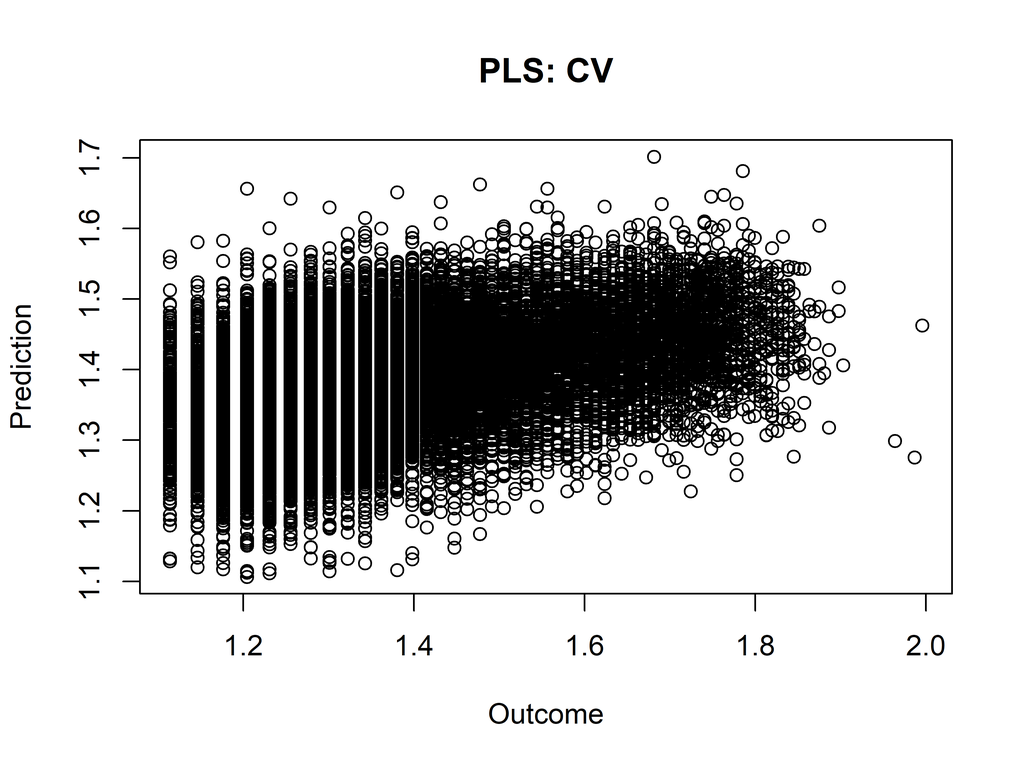

### 1.6.2 PC

```r
PCcv <- randomCV(fittingFunction = pcrfit,
                     trainSampleSets = PLScv$trainSamplesSets
                    )
```

……….10 Tested: 19303 Avg. Selected: 0 Min Tests: 2 Max Tests: 10 Mean Tests: 7.500389 . MAD: 0.1185272

```r
PCbs <- predictionStats_regression(PCcv$medianTest,"PCR: CV")
```

PCR: CV

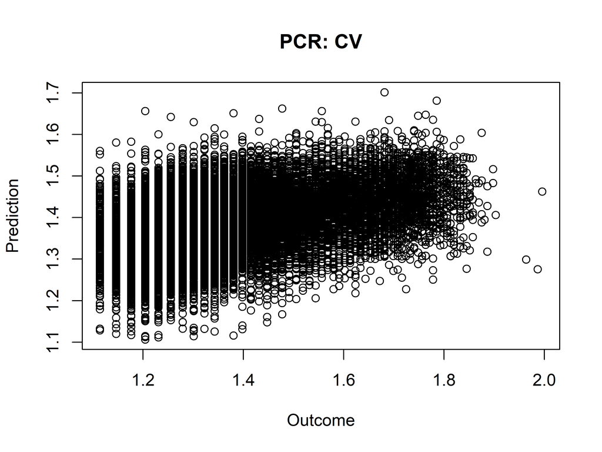

### 1.6.3 CPP

```r
#CPPlcv <- randomCV(fittingFunction = cpplsfit,
#                     trainSampleSets = PLScv$trainSamplesSets
#                    )

#CPPlbs <- predictionStats_regression(CPPlcv$medianTest,"cppls: CV")
```

### 1.6.4 LASSO

```r
LASSOcv <- randomCV(fittingFunction = LASSO_MIN,
                     trainSampleSets = PLScv$trainSamplesSets)
```

……….10 Tested: 19303 Avg. Selected: 48.5 Min Tests: 2 Max Tests: 10 Mean Tests: 7.500389 . MAD: 0.1185866

```r
LASSObs <- predictionStats_regression(LASSOcv$medianTest,"LASSO: CV")
```

LASSO: CV

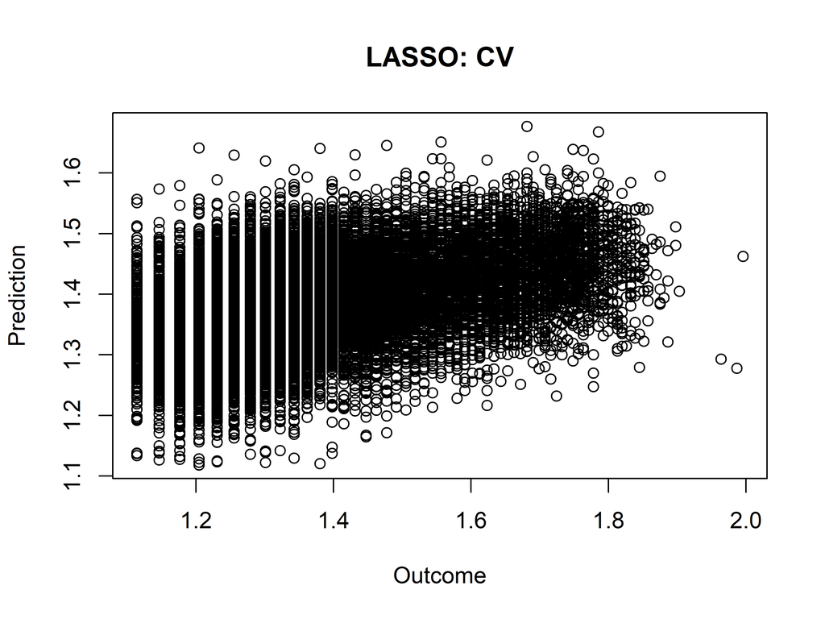

### 1.6.5 PCA LASSO

```r
PCALASSOcv <- randomCV(fittingFunction = filteredFit,
                     trainSampleSets = PLScv$trainSamplesSets,
                     fitmethod = LASSO_MIN,
                      filtermethod = NULL,
                    PCA = TRUE)
```

……….10 Tested: 19303 Avg. Selected: 47 Min Tests: 2 Max Tests: 10 Mean Tests: 7.500389 . MAD: 0.1186228

```r
PCALASSObs <- predictionStats_regression(PCALASSOcv$medianTest,"PCA-LASSO: CV")
```

PCA-LASSO: CV

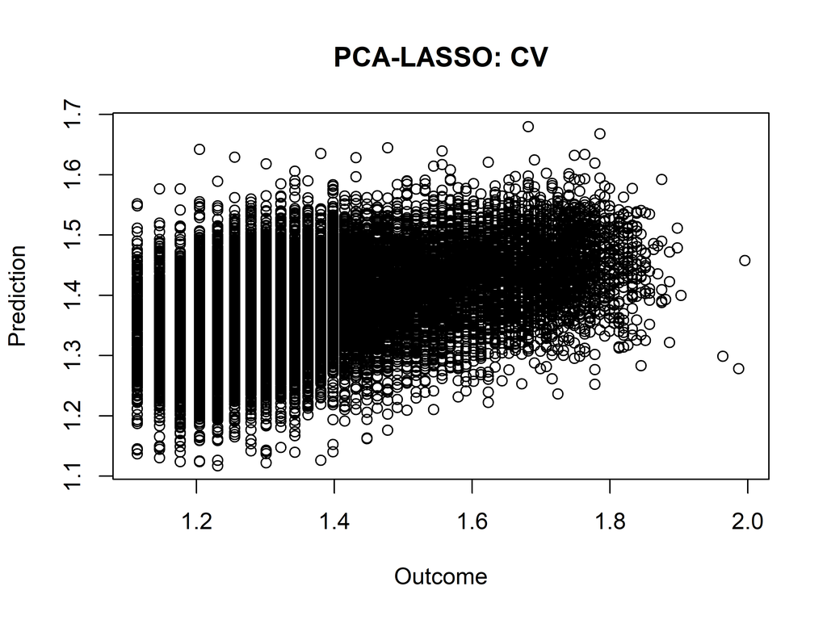

### 1.6.6 ILAA LASSO

```r
ILAALASSOcv <- randomCV(fittingFunction = filteredFit,
                     trainSampleSets = PLScv$trainSamplesSets,
                     fitmethod = LASSO_MIN,
                      filtermethod = NULL,
                    DECOR = TRUE,
                    DECOR.control=list(thr=thro,Outcome=outcome))
```

……….10 Tested: 19303 Avg. Selected: 49.3 Min Tests: 2 Max Tests: 10 Mean Tests: 7.500389 . MAD: 0.1186312

```r
ILAALASSObs <- predictionStats_regression(ILAALASSOcv$medianTest,"ILLA-LASSO: CV")
```

ILLA-LASSO: CV

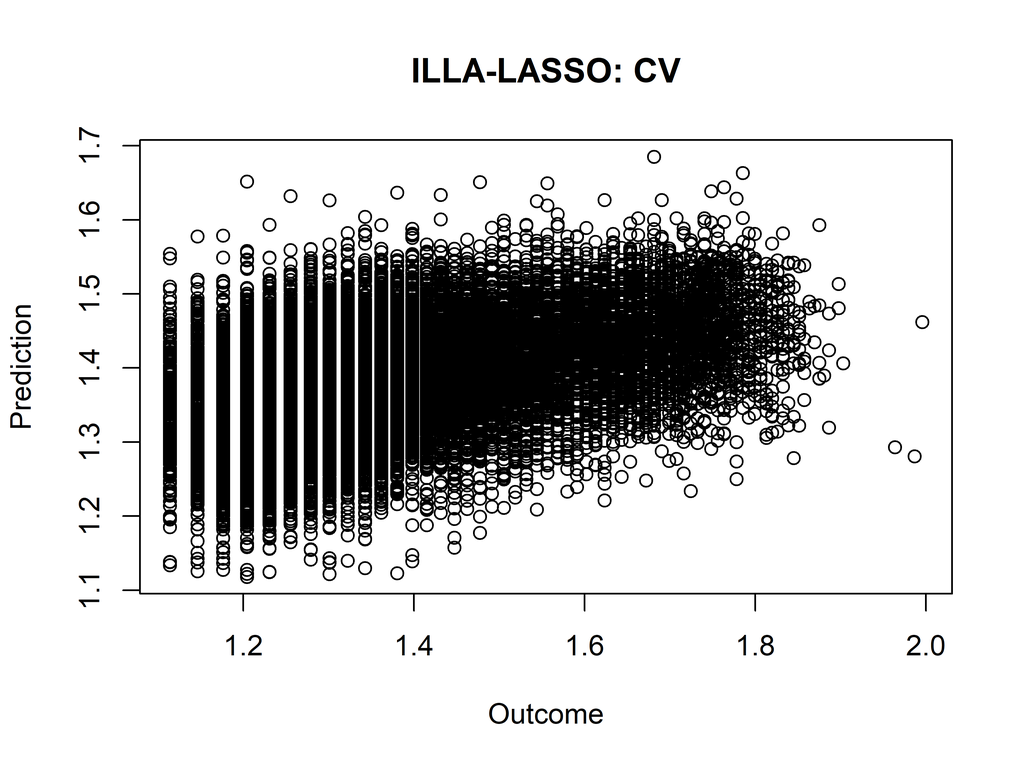

### 1.6.7 ENET

```r
ENETcv <- randomCV(fittingFunction = GLMNET_ELASTICNET_MIN,
                     trainSampleSets = PLScv$trainSamplesSets)
```

……….10 Tested: 19303 Avg. Selected: 47.1 Min Tests: 2 Max Tests: 10 Mean Tests: 7.500389 . MAD: 0.118654

```r
ENETbs <- predictionStats_regression(ENETcv$medianTest,"ENET: CV")
```

ENET: CV

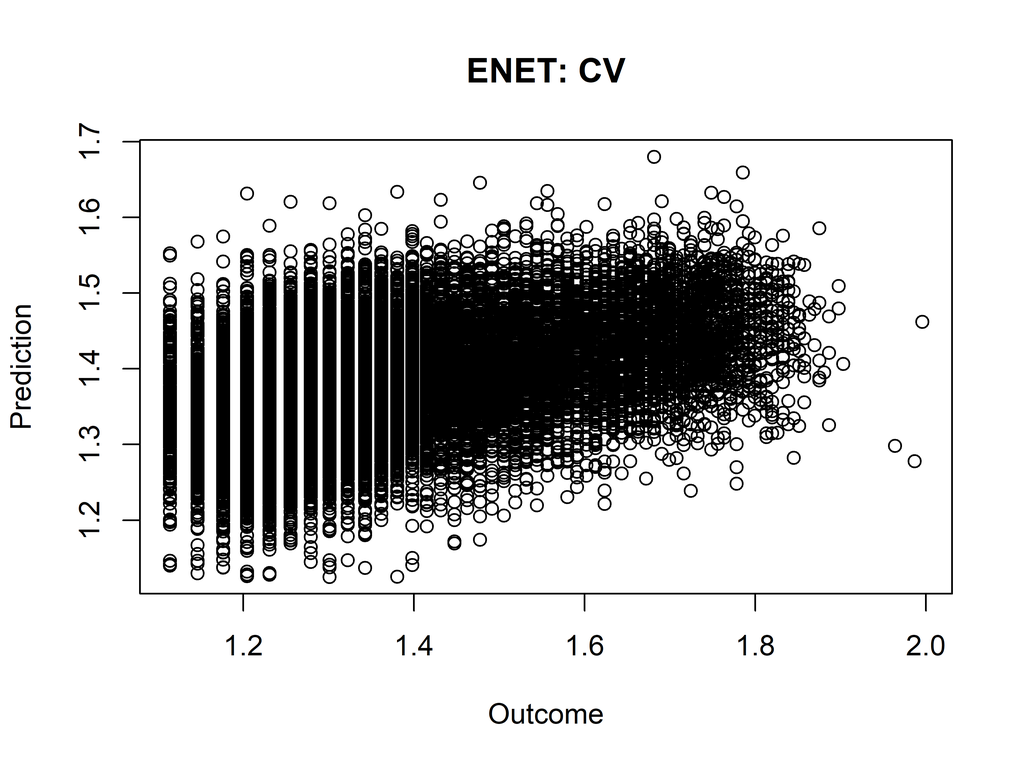

### 1.6.8 ILAAA ENET

```r
ILAAENETcv <- randomCV(fittingFunction = filteredFit,
                     trainSampleSets = PLScv$trainSamplesSets,
                     fitmethod = GLMNET_ELASTICNET_MIN,
                      filtermethod = NULL,
                    DECOR = TRUE,
                    DECOR.control=list(thr=thro,Outcome=outcome))
```

……….10 Tested: 19303 Avg. Selected: 46.9 Min Tests: 2 Max Tests: 10 Mean Tests: 7.500389 . MAD: 0.1187088

```r
ILAAENETbs <- predictionStats_regression(ILAAENETcv$medianTest,"ILLA-ENET: CV")
```

ILLA-ENET: CV

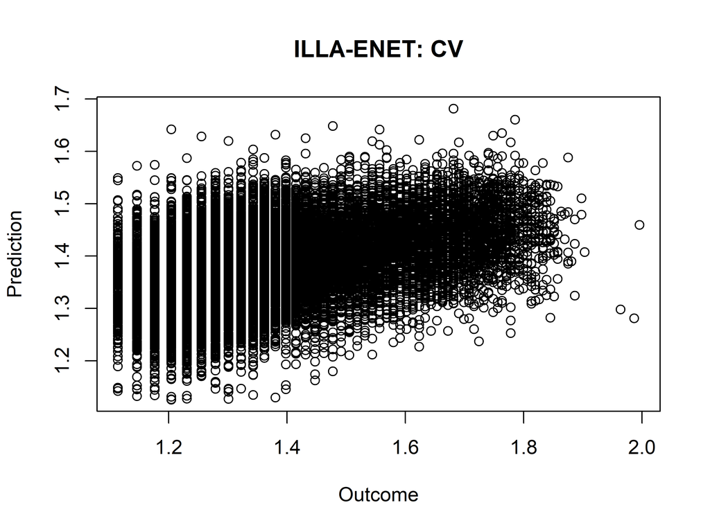

## 1.7 The Reports

```r
par(op)
RMSTABLE <- rbind(
                  PLSbs$RMSEci,
                  PCbs$RMSEci,
#                  CPPlbs$RMSEci,
                  LASSObs$RMSEci,
                  PCALASSObs$RMSEci,
                  ILAALASSObs$RMSEci,
                  ENETbs$RMSEci,
                  ILAAENETbs$RMSEci
                  )
colnames(RMSTABLE) <- c("Median","Lower","Upper")
#rownames(RMSTABLE) <- c("PLSR","PCR","CPP",
#                        "LASSO","PCA-LASSO","ILAA-LASSO","ENET","ILAA-ENET")

rownames(RMSTABLE) <- c("PLSR","PCR",
                        "LASSO","PCA-LASSO","ILAA-LASSO",
                        "ENET","ILAA-ENET")

pander::pander(RMSTABLE)
```

|  | Median | Lower | Upper |
| --- | --- | --- | --- |
| **PLSR** | 0.148 | 0.147 | 0.149 |
| **PCR** | 0.148 | 0.147 | 0.149 |
| **LASSO** | 0.148 | 0.147 | 0.149 |
| **PCA-LASSO** | 0.148 | 0.147 | 0.149 |
| **ILAA-LASSO** | 0.148 | 0.147 | 0.150 |
| **ENET** | 0.148 | 0.147 | 0.150 |
| **ILAA-ENET** | 0.148 | 0.147 | 0.150 |

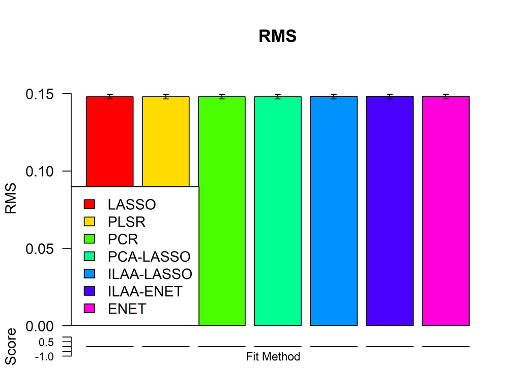

```r
themethod <- rownames(RMSTABLE)
thesets <- c("Fit Method")
pRMS <- barPlotCiError(RMSTABLE,
               "RMS",
               thesets=thesets,
               themethod=themethod,
               main="RMS",
               angle=0,
               offsets=c(0.1,1.0),
               scoreDirection="<",args.legend=list(x="bottomleft"),
               col=rainbow(length(themethod)))

par(op)
```

```r
MADTABLE <- rbind(
                  PLSbs$MAEci,
                  PCbs$MAEci,
#                  CPPlbs$MAEci,
                  LASSObs$MAEci,
                  PCALASSObs$MAEci,
                  ILAALASSObs$MAEci,
                  ENETbs$MAEci,
                  ILAAENETbs$MAEci
                  )


colnames(MADTABLE) <- colnames(RMSTABLE)
rownames(MADTABLE) <- rownames(RMSTABLE)

pander::pander(MADTABLE)
```

|  | Median | Lower | Upper |
| --- | --- | --- | --- |
| **PLSR** | 0.119 | 0.117 | 0.12 |
| **PCR** | 0.119 | 0.117 | 0.12 |
| **LASSO** | 0.119 | 0.117 | 0.12 |
| **PCA-LASSO** | 0.119 | 0.117 | 0.12 |
| **ILAA-LASSO** | 0.119 | 0.117 | 0.12 |
| **ENET** | 0.119 | 0.117 | 0.12 |
| **ILAA-ENET** | 0.119 | 0.117 | 0.12 |

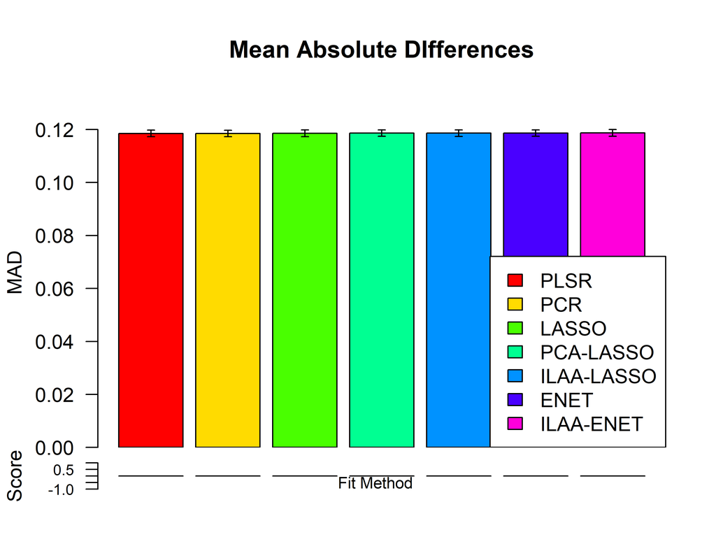

```r
pber <- barPlotCiError(MADTABLE,
               "MAD",
               thesets=thesets,
               themethod=themethod,
               main="Mean Absolute DIfferences",
               angle=0,
               offsets=c(0.1,0.5),
               scoreDirection="<",args.legend=list(x="bottomright"),
               col=rainbow(length(themethod))
               )
```

```r
PearsonTABLE <- rbind(
                  PLSbs$corci,
                  PCbs$corci,
#                  CPPlbs$corci,
                  LASSObs$corci,
                  PCALASSObs$corci,
                  ILAALASSObs$corci,
                  ENETbs$corci,
                  ILAAENETbs$corci
                  )


colnames(PearsonTABLE) <- colnames(RMSTABLE)
rownames(PearsonTABLE) <- rownames(RMSTABLE)

pander::pander(PearsonTABLE)
```

|  | Median | Lower | Upper |
| --- | --- | --- | --- |
| **PLSR** | 0.445 | 0.434 | 0.456 |
| **PCR** | 0.445 | 0.434 | 0.456 |
| **LASSO** | 0.445 | 0.434 | 0.456 |
| **PCA-LASSO** | 0.445 | 0.434 | 0.456 |
| **ILAA-LASSO** | 0.445 | 0.433 | 0.456 |
| **ENET** | 0.445 | 0.433 | 0.456 |
| **ILAA-ENET** | 0.445 | 0.433 | 0.456 |

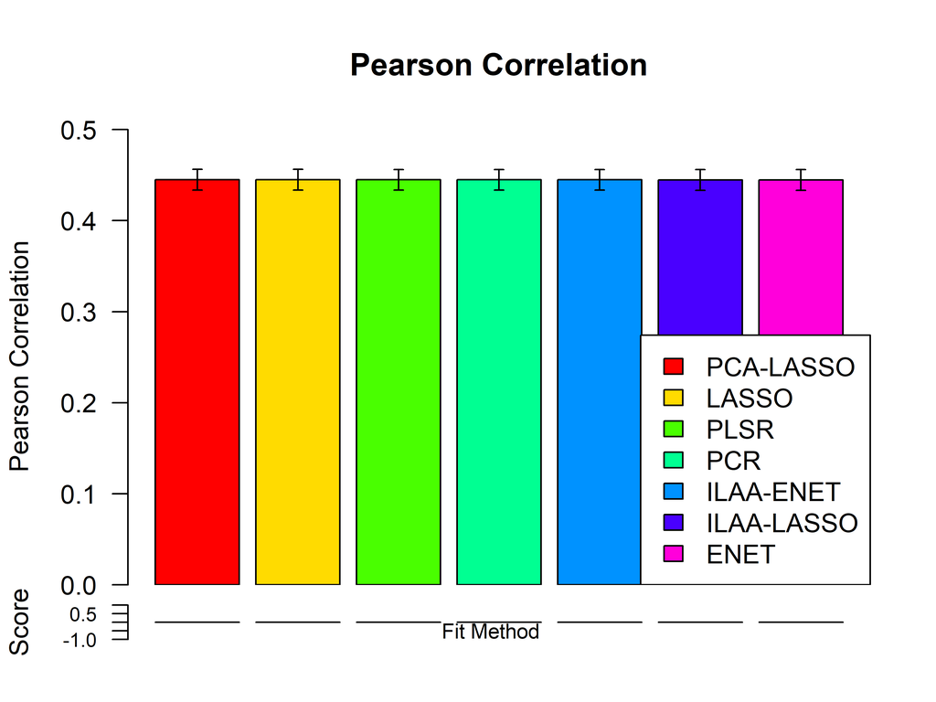

```r
pber <- barPlotCiError(PearsonTABLE,
               "Pearson Correlation",
               thesets=thesets,
               themethod=themethod,
               main="Pearson Correlation",
               angle=0,
               offsets=c(0.1,0.5),
               scoreDirection=">",args.legend=list(x="bottomright"),
               col=rainbow(length(themethod))
               )
```

### 1.7.1 Saving ALL

```r
save.image(paste("SOTACV_analyiss",studyName,".RData",sep="_"))
```